# Modelaje Epidemiológico en `R`

Veamos, ahora, qué pasa, si mis datos no son lineales: ¿cómo se ven las gráficas?

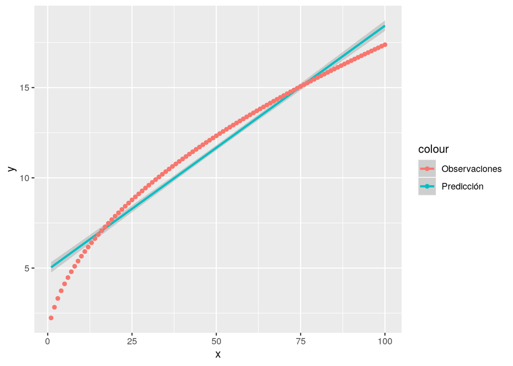

```r
base3 <- base1 %>% mutate(y = sqrt(y))

ggplot(base3, aes(x = x, y = y)) +
  geom_smooth(aes(x = x, y = y, color = "Predicción"), method = "lm") +
  geom_point(aes(x = x, y = y, color = "Observaciones"))
```

Por otro lado observa el modelo ¿qué notas?

```r
modelo3 <- lm(x ~ y, data = base3)
summary(modelo3)
```

```
##
## Call:
## lm(formula = x ~ y, data = base3)
##
## Residuals:
##    Min     1Q Median     3Q    Max
## -5.606 -4.572 -1.561  3.566 18.357
##
## Coefficients:
##             Estimate Std. Error t value Pr(>|t|)
## (Intercept) -33.3299     1.6680  -19.98   <2e-16 ***
## y             7.1433     0.1346   53.06   <2e-16 ***
## ---
## Signif. codes:  0 '***' 0.001 '**' 0.01 '*' 0.05 '.' 0.1 ' ' 1
##
## Residual standard error: 5.348 on 98 degrees of freedom
## Multiple R-squared:  0.9664, Adjusted R-squared:  0.966
## F-statistic:  2815 on 1 and 98 DF,  p-value: < 2.2e-16
```

¿Ahora qué ves en las gráficas de diagnóstico?

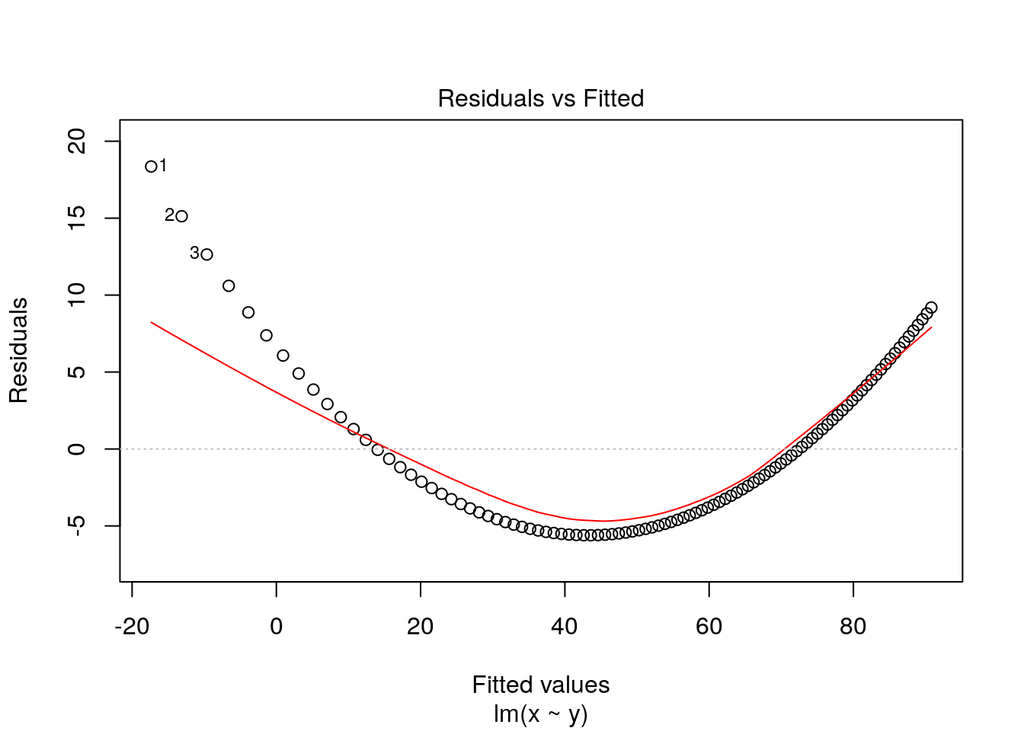

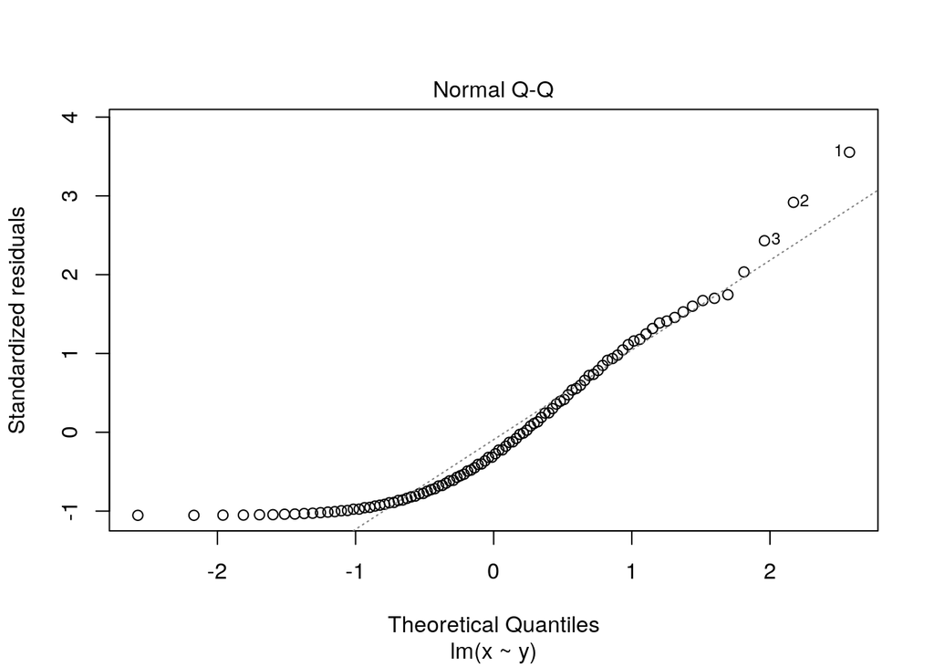

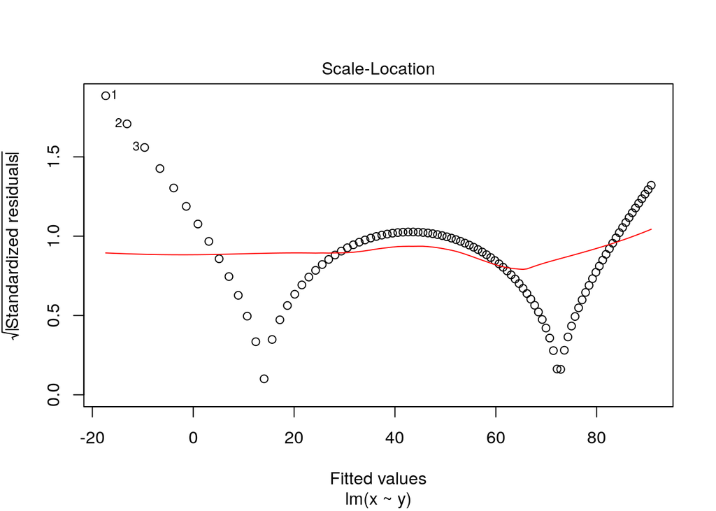

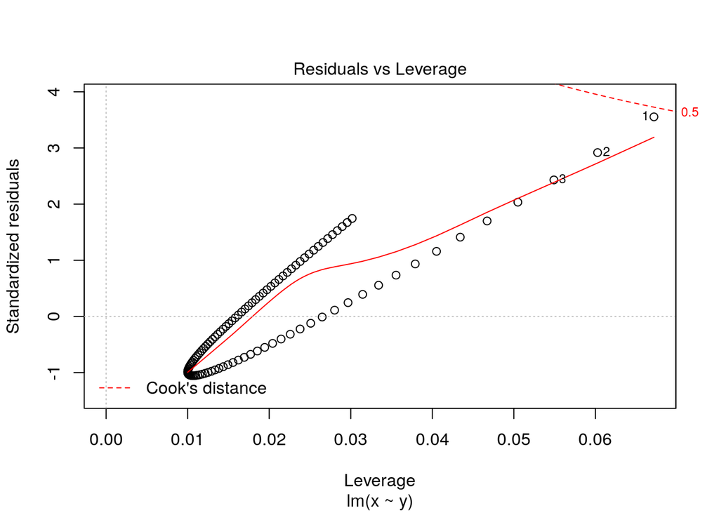

```r
plot(modelo3)
```

## Ejercicio

Lee las bases de datos de `R` llamadas `Anscombe.Rda`. Ellas contienen mediciones de conteo de glóbulos blancos contra dosis de una medicina clasificados por uno de cuatro grupos de edad. Para cada grupo de edad:

1. Realiza un modelo de regresión y observa el `summary`. No grafiques. Determina sólo con el `summary` cuáles modelos sí funcionan y cuáles no.
2. Observa las gráficas de diagnóstico. Determina sólo con las gráficas de diagnóstico cuál es un buen modelo y cuáles no.
3. Finalmente, grafica los datos y verifica tu análisis.

Así se ve la base de datos:

| Glóbulos | Dosis | Grupo |
| --- | --- | --- |
| 10 | 10 | Grupo 1 |
| 8 | 8 | Grupo 1 |
| 13 | 13 | Grupo 1 |
| 9 | 9 | Grupo 1 |
| 11 | 11 | Grupo 1 |
| 14 | 14 | Grupo 1 |

## Análisis con datos no lineales

Las base de datos `Datos_Peso.rda` contiene la información de el peso, altura y sexo de una persona. Lee la base de datos:

```r
load("Datos_Peso.rda")
```

Los datos deberían de verse así:

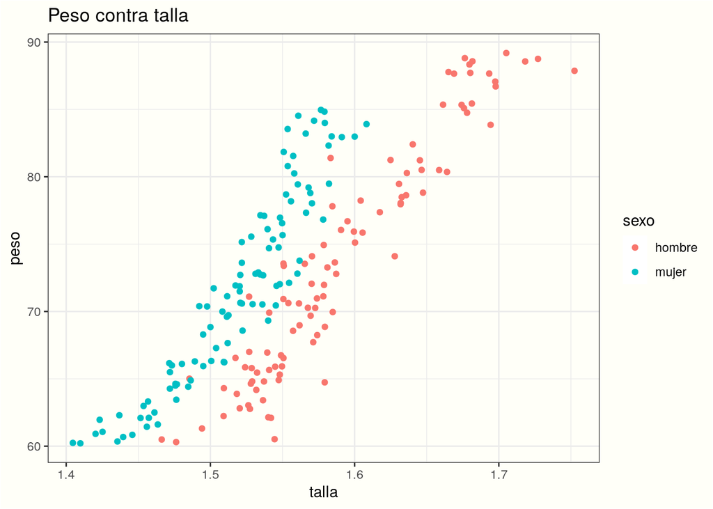

Vamos a ajustar un modelo para los registros de `hombre`. Para ello obtenemos una subbase usando `filter`:

```r
datos.h <- datos_peso %>% filter(sexo == "hombre")
```

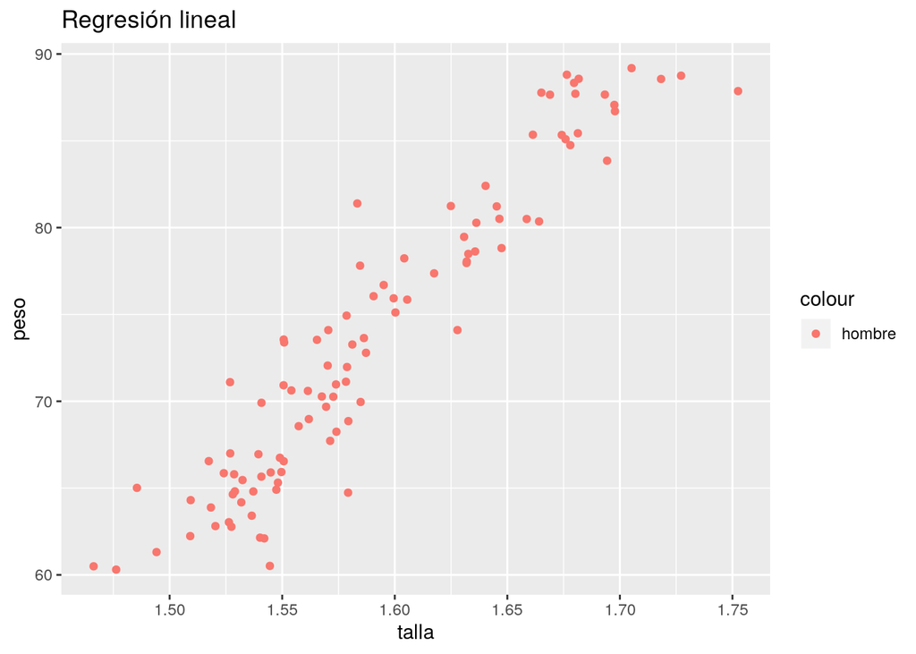

```r
ggplot(datos.h, aes(x = talla, y = peso, color = "hombre")) + geom_point() +
  ggtitle("Regresión lineal")
```

Pero cuando corremos el modelo de mujeres, el ajuste no es muy bueno:

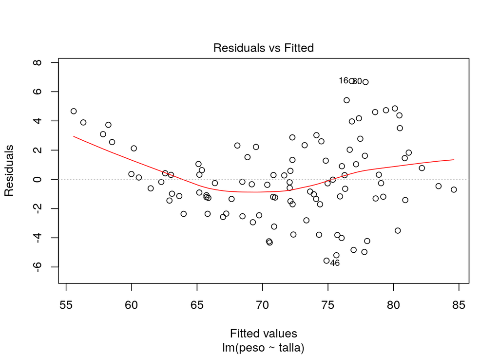

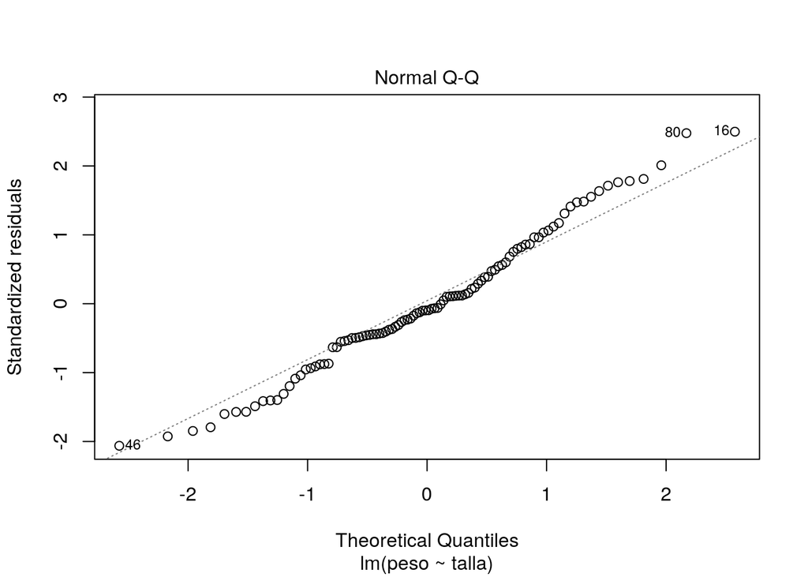

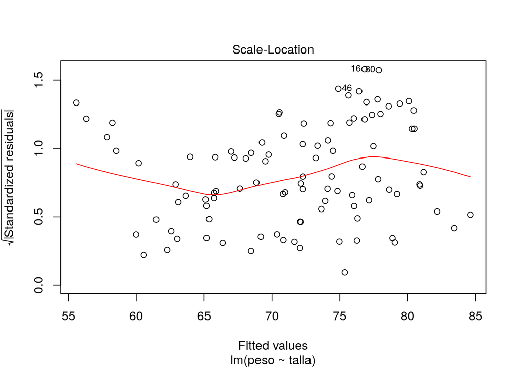

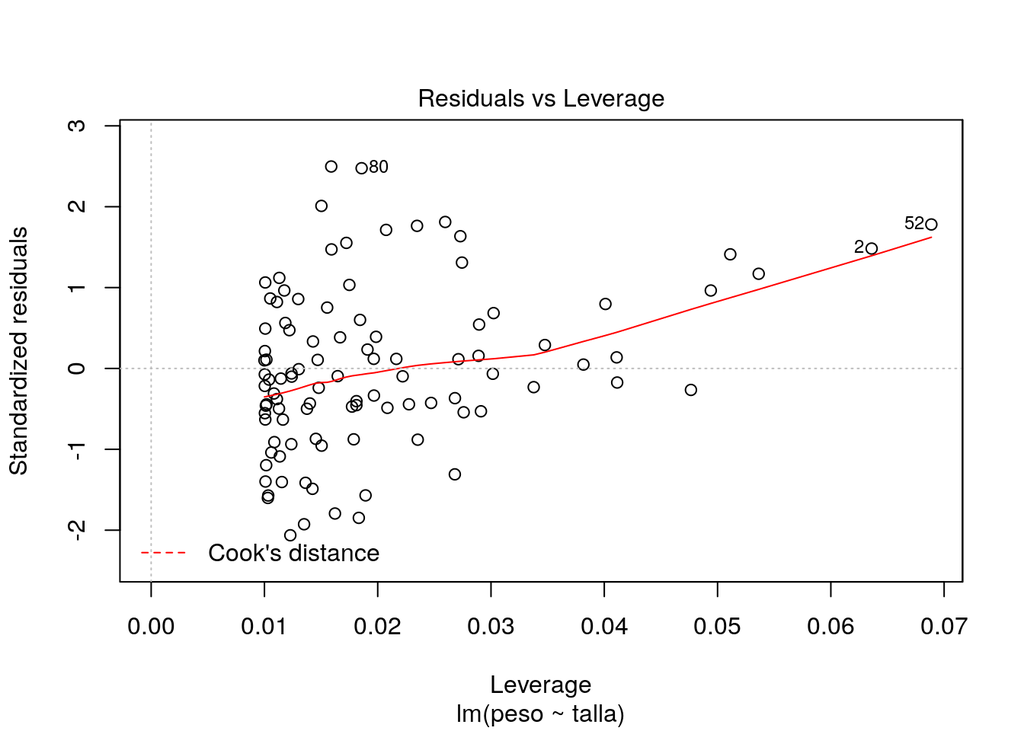

```r
datos.m  <- datos_peso %>% filter(sexo == "mujer")
modelo.m <- lm(peso ~ talla, data = datos.m)
plot(modelo.m)
```

No está ajustando bien la curvatura del modelo:

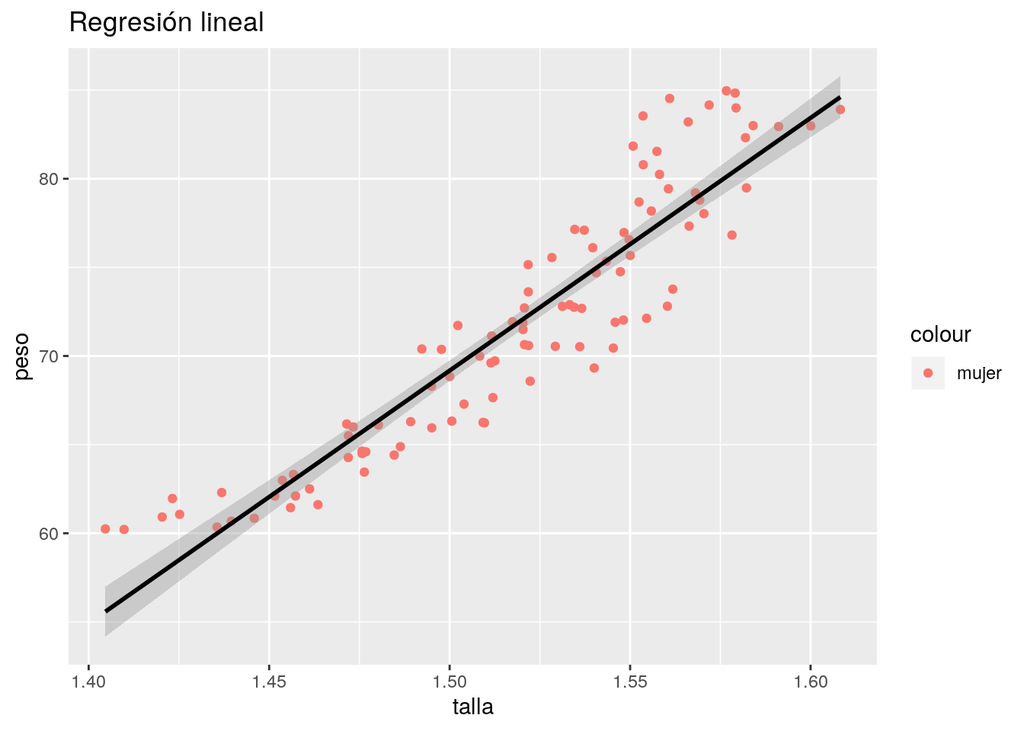

```r
ggplot(datos.m, aes(x = talla, y = peso, color = "mujer")) +
  geom_point() +
  geom_smooth(method = "lm", color = "black") +
  ggtitle("Regresión lineal")
```

Para ello necesitamos transformar los datos. Como yo inventé los datos, sé que elevar al cuadrado es justo lo que necesitamos:

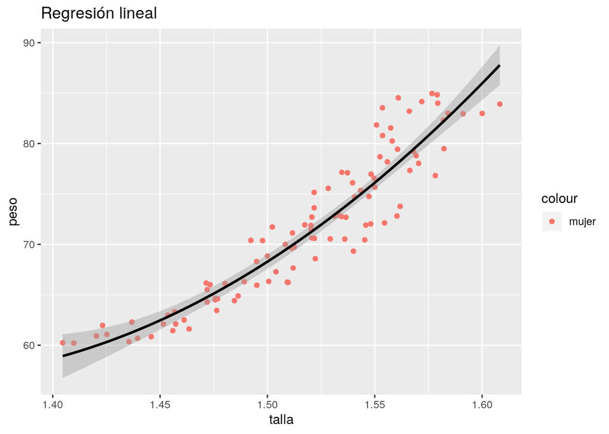

```r
ggplot(datos.m, aes(x = talla, y = peso, color = "mujer")) +
  geom_point() +
  geom_smooth(method = "lm", color = "black", formula = y ~ poly(x, 2)) +
  ggtitle("Regresión lineal")
```

Lo podemos ver en el análisis también:

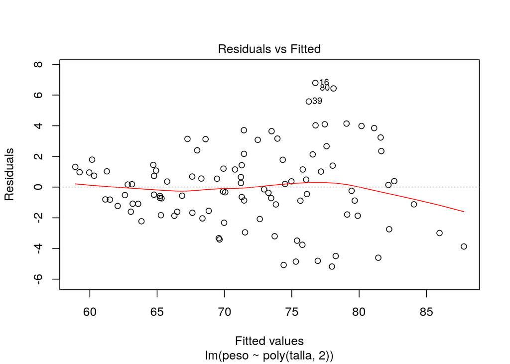

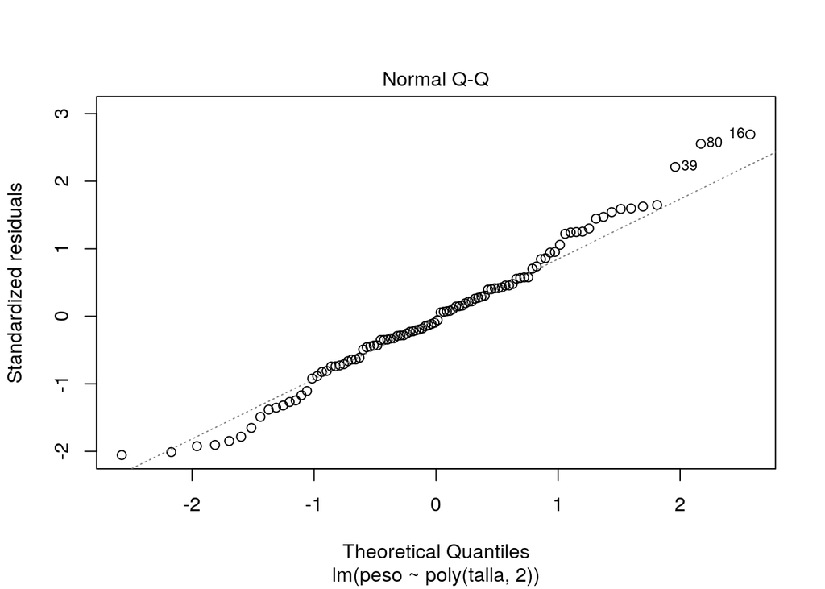

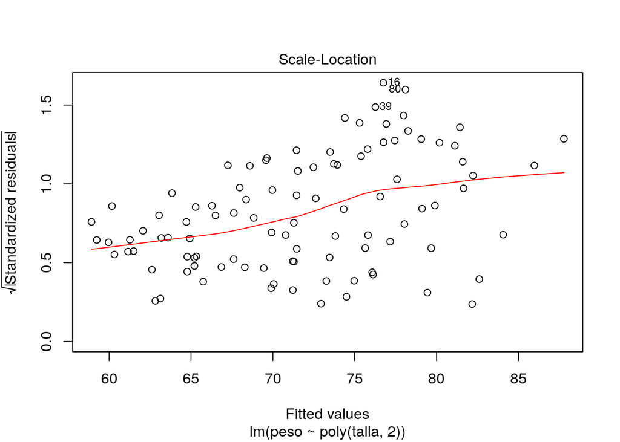

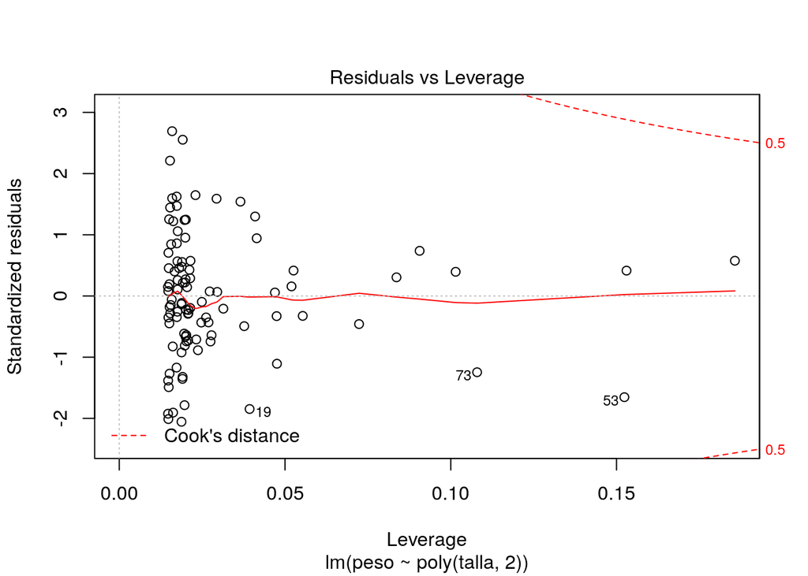

```r
modelo.m.cuad <- lm(peso ~ poly(talla, 2), data = datos.m)
plot(modelo.m.cuad)
```

# Regresión logística

## Idea

## Verificación del modelo

## Regresión kernel

## Modelos aditivos generalizados

## Regresión de Cox

## Regresión Poisson

## Series de tiempo

El libro que te recomiendo para esta sección es: [Forecasting: Principles and Practice por Rob J Hyndman and George Athanasopoulos](https://otexts.com/fpp2/)

Vamos a analizar la base de mortalidad generada en los apuntes pasados. Para eso puedes leer:

```r
Miocardio <- readRDS(paste0(filedir,"MortalidadAgrupada.rds"))
```

Recuerda que los datos se ven así:

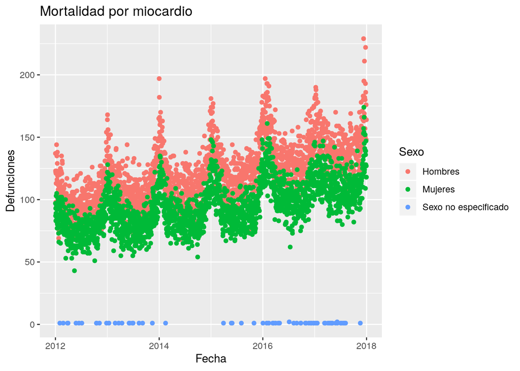

```r
ggplot(Miocardio, aes(x = Fecha, y = Defunciones, color = Sexo)) +
  geom_point() + ggtitle("Mortalidad por miocardio")
```

Trabajaremos sólo la base de mujeres:

```r
Miocardio.m <- Miocardio %>% filter(Sexo == "Mujeres")
```

Instala los paquetes necesarios:

```r
install.packages("ggseas")
install.packages("forecast")
```

¡No olvides llamarlos con la librería!

```r
library(forecast)
library(ggseas)
```

## Bosques aleatorios